# MICCAI Educational Challenge: Survival Analysis

# 1 Introduction

A prognostic model should not enter clinical practice unless it has been demonstrated that it performs a useful role. External validation denotes evaluation of model performance in a sample independent of that used to develop the model. Unlike for logistic regression models, external validation of Cox models is sparsely treated in the literature. Successful validation of a model means achieving satisfactory discrimination and calibration (prediction accuracy) in the validation sample. Validating Cox models is not straightforward because event probabilities are estimated relative to an unspecified baseline function.

# 2 R Preliminaries and Data Load/Merge

## 2.1 Initial Setup and Package Loads in R

```r
library(knitr); library(rmdformats); library(rmarkdown)
library(simputation); library(skimr); library(magrittr); library(dplyr);
library(broom); library(GGally); library(car) ; library(survival); library(Hmisc); library(Epi); library(vcd);  library(survival);library(survminer);library(tidyverse)

source("Love-boost.R")

## Global options

options(max.print="75")
opts_chunk$set(comment=NA,
               message=FALSE,
               warning=FALSE)
opts_knit$set(width=75)

skimr::skim_with(numeric = list(hist = NULL),
                 integer = list(hist = NULL))
```

## 2.2 Loading the Raw Data into R

For this tutorial, we will use publicly available The Cancer Genome Atlas (TCGA) data. This data contains clinical information for Lung Cancer patients.

```r
ESNSCLC_study <- read_csv("TCGA.csv") %>%
  mutate_if(is.character, funs(as.factor(.))) %>%
  mutate(subj_id = as.character(subj_id))
```

## 2.3 Data Management: Building a Tidy Data Set

For the early-stage lung cancer patients, following clinical variables are considered prognostic. For this tutorial, we would take following variables for the analysis:

```r
Data1 <- ESNSCLC_study %>%
  select(subj_id, time, status, diagnosis, pathologic_T , pathologic_N, pathologic_M,  pathologic_stage, smoking_history, Recurrence)

head(Data1,3)
```

| subj_id | time | status | diagnosis | pathologic_T | pathologic_N | pathologic_M | pathologic_stage | smoking_history | Recurrence |
| --- | --- | --- | --- | --- | --- | --- | --- | --- | --- |
| TCGA-05-4244 | 0 | 1 | Lung Adenocarcinoma | T2 | N2 | M1 | Stage IV | 1 | 0 |
| TCGA-05-4245 | 334 | 2 | Lung Adenocarcinoma | T2 | N2 | M0 | Stage IIIA | 1 | 0 |
| TCGA-05-4249 | 1523 | 1 | Lung Adenocarcinoma | T2 | N0 | M0 | Stage IB | 2 | 0 |

## 2.4 Cleaning missing data

In any analysis, it is important to define definite inclusion and exlusion criteria. Here, we would look at 5 years’ disease-free survival with minimum 2 months follow-up.

```r
Data <- subset(Data1, ( time<2000 &time>60))
```

Here are the missing values according to the variables

```r
colSums(is.na(Data))
```

```
         subj_id             time           status        diagnosis
               0                0                0                0
    pathologic_T     pathologic_N     pathologic_M pathologic_stage
               0                0                4                0
 smoking_history       Recurrence
              22              156
```

We would exclude patients with missing elements.

```r
Data_fixed <- Data%>%
  na.omit(pathologic_M) %>%
  na.omit(Recurrence) %>%
  na.omit(smoking_history)
```

## 2.5 Final data set

Here is a final data set, called `Main_Data` that contains `10 variables` and `669 patients` in the code book.

```r
Main_Data <- Data_fixed
Main_Data
```

| subj_id | time | status | diagnosis | pathologic_T | pathologic_N | pathologic_M | pathologic_stage | smoking_history | Recurrence |
| --- | --- | --- | --- | --- | --- | --- | --- | --- | --- |
| TCGA-05-4245 | 334 | 2 | Lung Adenocarcinoma | T2 | N2 | M0 | Stage IIIA | 1 | 0 |
| TCGA-05-4249 | 1523 | 1 | Lung Adenocarcinoma | T2 | N0 | M0 | Stage IB | 2 | 0 |
| TCGA-05-4382 | 334 | 2 | Lung Adenocarcinoma | T2 | N0 | M0 | Stage IB | 1 | 0 |
| TCGA-05-4389 | 1369 | 1 | Lung Adenocarcinoma | T1 | N0 | M0 | Stage IA | 2 | 0 |
| TCGA-05-4390 | 395 | 2 | Lung Adenocarcinoma | T2 | N0 | M0 | Stage IB | 1 | 0 |
| TCGA-05-4398 | 1431 | 1 | Lung Adenocarcinoma | T4 | N3 | M0 | Stage IIIB | 4 | 0 |
| TCGA-05-4402 | 244 | 2 | Lung Adenocarcinoma | T2 | NX | M1 | Stage IV | 0 | 0 |
| TCGA-05-4405 | 610 | 1 | Lung Adenocarcinoma | T2 | N0 | M0 | Stage IB | 1 | 0 |
| TCGA-05-4417 | 455 | 1 | Lung Adenocarcinoma | T2 | N0 | M0 | Stage IB | 1 | 0 |
| TCGA-05-4420 | 912 | 1 | Lung Adenocarcinoma | T2 | N0 | M0 | Stage IB | 4 | 0 |

[output cut: 65 more lines]

# 3 The Codebook

The 10 variables in our tidy data set for this demonstration are as follows.

[output not shown]

# 4 Identify training and test samples

The training sample is called `ESNSCLC_train` and test sample `ESNSCLC_test`

```r
set.seed(1311994)

ESNSCLC_train <- Main_Data%>% sample_frac(.75)
ESNSCLC_test <- anti_join(Main_Data, ESNSCLC_train, by = "subj_id")

dim(Main_Data) # number of rows and columns in Main_Data
```

```
[1] 669  10
```

```r
dim(ESNSCLC_train) # check to be sure we have 80% of Main_Data here
```

```
[1] 502  10
```

```r
dim(ESNSCLC_test) # check to be sure we have the rest of Main_Data here
```

```
[1] 167  10
```

The training data has `502 patients` and the testing data has `167 patients`. We will use training data to build the model and we will validate the developed model on the testing ser.

# 5 Summarize the outcome and the predictors

If we want to consider survival time as a continuous variable, it is very important to look at the distribution of the data. Usually,the survival data is skewed. If we want to compare distribution of survival across different predictors or build a linear models, we have to account for the distribution and skew.

```r
mosaic::favstats(ESNSCLC_train$time)
```

|  | min | Q1 | median | Q3 | max | mean | sd | n | missing |
| --- | --- | --- | --- | --- | --- | --- | --- | --- | --- |
|  | 61 | 334 | 554 | 926.5 | 1984 | 663.5757 | 442.7073 | 502 | 0 |

## 5.1 Visualizing the Distribution of Survival

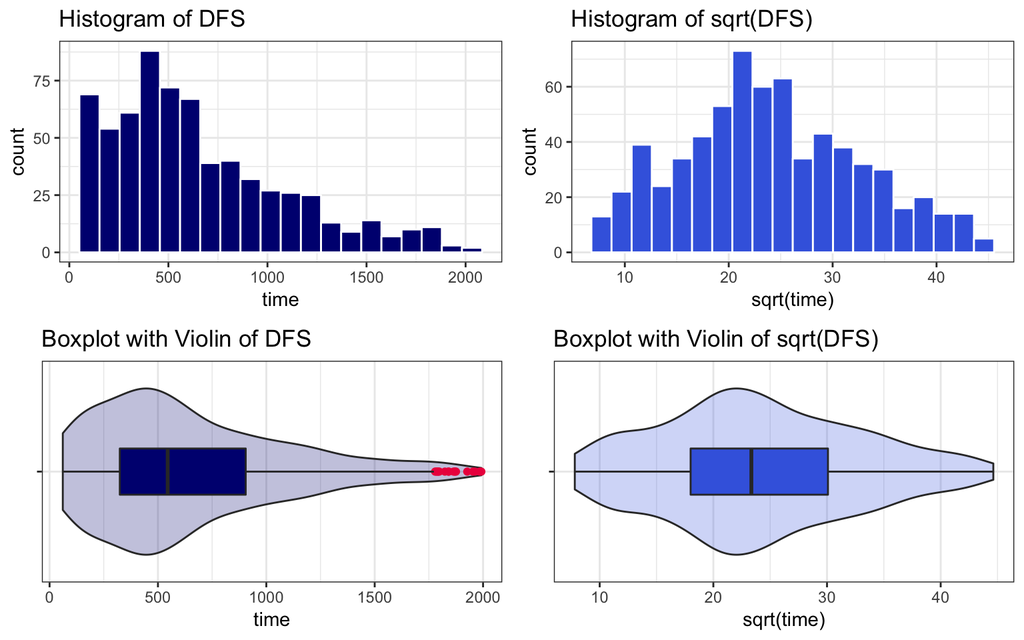

```r
p1 <- ggplot(Main_Data, aes(x = time)) +
  geom_histogram(bins = 20,
                 col = "white", fill = "navy", outlier.color = "#ED174C") +
  theme_bw() +
  labs(title = "Histogram of DFS")
p2 <- ggplot(Main_Data, aes(x = sqrt(time))) +
  geom_histogram(bins = 20,
                 col = "white", fill = "royalblue",  outlier.color = "#ED174C") +
  theme_bw() +
  labs(title = "Histogram of sqrt(DFS)")
p3 <- ggplot(Main_Data, aes(x = "", y = time)) +
  geom_violin(fill = "navy", alpha = 0.25) +
  geom_boxplot(width = 0.25, fill = "navy",  outlier.color = "#ED174C") +
  coord_flip() +
  theme_bw() +
  labs(title = "Boxplot with Violin of DFS",
       x = "")
p4 <- ggplot(Main_Data, aes(x = "", y = sqrt(time))) +
  geom_violin(fill = "royalblue", alpha = 0.25) +
  geom_boxplot(width = 0.25, fill = "royalblue",  outlier.color = "#ED174C") +
  coord_flip() +
  theme_bw() +
  labs(title = "Boxplot with Violin of sqrt(DFS)",
       x = "")
gridExtra::grid.arrange(p1, p2, p3, p4, nrow = 2)
```

We can see from the box-plot and histogram for the distribution of survival, there are a couple of outliers and a little right skew.

At the right side, two plots show the square root transformation of data. Although the skew is not large, the square-root transformed data gives much better normal distribution.

## 5.2 Statistical Significane tests.

### 5.2.1 Confidence Interval

A `confidence interval` for a population can be defined as a range of potential values for the population mean which, if certain assumptions hold, can be assumed to provide a reasonable estimate for the true population mean.

### 5.2.2 Confidence Interval Tests

| Test | Type | Assumptions |
| --- | --- | --- |
| `Welch t-test` | Estimates Population Mean | The population follows a Normal distribution. At the very least, the sample itself is approximately `Normal` |
| `Pooled t-test` | Estimates Population Mean | The population follows a Normal distribution. At the very least, the sample itself is approximately `Normal` |
| `Wilcoxon-Signed Rank Test` | Estimates Population Median | The population follows a symmetric distribution. At the very least, the sample itself shows no substantial skew, so that the sample `pseudo-median` is a reasonable estimate for the population median. |
| `Bootstrap confidence interval` | Estimates Population Mean (or Median) | We are willing to put up with the fact that different people (not using the same random seed) will get somewhat different confidence interval estimates using the same data. |

### 5.2.3 Choosing a confidence interval approach:

Suppose we want to find a confidence interval for the mean of a population, μ, or, the population mean difference μd between two populations based on matched pairs. 1. If we are willing to assume that the population distribution is Normal • and that the population SD is known, we can use a Z-based CI. • and the population SD isn’t known, we can use a t-based CI.

2. If we are unwilling to assume that the population is Normal, • We can use a bootstrap procedure to get a CI for the population mean, or even the median

• If we are willing to assume the population is symmetric, we can consider a Wilcoxon signed rank procedure to get a CI for the median, rather than the mean.

## 5.3 Graphical Summary

In this analysis we will use time (DFS) as a quantitative variable and see its comparison against recurence.

```r
mosaic::favstats(time ~ Recurrence, data = Main_Data) %>%
  knitr::kable()
```

[output not shown]

```r
by(Main_Data$time,Main_Data$Recurrence, skew1)
```

```
Main_Data$Recurrence: 0
[1] 0.2393902
--------------------------------------------------------
Main_Data$Recurrence: 1
[1] 0.216617
```

It can be also observed on a normal q-q plot for time in two groups (recurrence and non-recurrence)

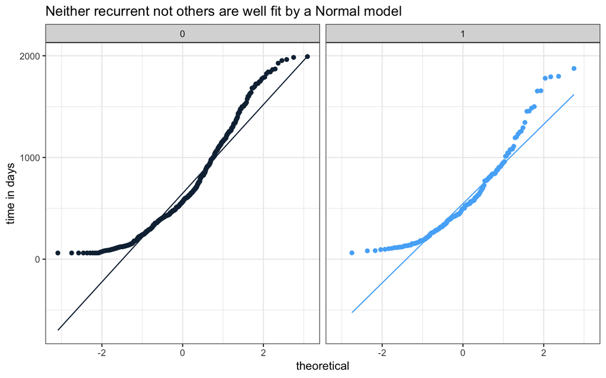

```r
ggplot(Main_Data, aes(sample = time, col = Recurrence)) +
  geom_qq() + geom_qq_line() +
  facet_wrap(~ Recurrence) +
  guides(col = FALSE) +
  theme_bw() + scale_fill_viridis_d(option = "cividis") +
  labs(y = "time in days",
       title = "Neither recurrent not others are well fit by a Normal model")
```

As per we noted previously, both groups have a little right skew.

## 5.4 Building a confidence interval

The confidence interval is built using different methods. For this scenario, boot-strap method would be ideal because of three reason.

We can avoid normal-distribution constraint. The different distribution across two groups would work. The mean and median are not equal, it would be better to avoid wilcoxon test which considers pseudo-median

```r
set.seed(311994)
bootdif(Main_Data$time,Main_Data$Recurrence,conf.level = 0.95)
```

```
Mean Difference           0.025           0.975
      -89.34681      -159.54649       -14.98581
```

Calculating 95% Confidence Interval using wilcoxon signed rank-test:

```r
wilcox.test(Main_Data$time ~ Main_Data$Recurrence, conf.level = .95, conf.int = TRUE, exact = FALSE)
```

```
    Wilcoxon rank sum test with continuity correction

data:  Main_Data$time by Main_Data$Recurrence
W = 46848, p-value = 0.02798
alternative hypothesis: true location shift is not equal to 0
95 percent confidence interval:
   8.000046 140.999927
sample estimates:
difference in location
              73.00003
```

Calculating 95% Confidence Interval using t-test:

```r
t.test(time ~ Recurrence, data = Main_Data, conf.level = .95)
```

```
    Welch Two Sample t-test

data:  time by Recurrence
t = 2.3965, df = 315.18, p-value = 0.01713
alternative hypothesis: true difference in means is not equal to 0
95 percent confidence interval:
  15.99369 162.69992
sample estimates:
mean in group 0 mean in group 1
       674.9301        585.5833
```

# 6 Building a model: Kitchen Sink Assessment

A “kitchen sink” cox-proportional hazard model is designed to describe the relationship between the survival and each of the predictors. Here, created a kitchen-sink model with all clinical factors.

## 6.1 Fitting/Summarizing the Kitchen Sink model

This “kitchen sink” or “large” model predicts `time` using all the predictors.

```r
ksink_model <- coxph(Surv((time), status) ~  diagnosis + pathologic_T + pathologic_N + pathologic_M +  pathologic_stage +smoking_history , data = ESNSCLC_train)
```

## 6.2 Interpreting the Model Summary

```r
glance(ksink_model)
```

| n | nevent | statistic.log | p.value.log | statistic.sc | p.value.sc | statistic.wald | p.value.wald | r.squared | r.squared.max | concordance | std.error.concordance | logLik | AIC | BIC |
| --- | --- | --- | --- | --- | --- | --- | --- | --- | --- | --- | --- | --- | --- | --- |
| 502 | 254 | 50.22925 | 0.002951826 | 66.96405 | 1.816416e-05 | 56.82 | 0.0004422057 | 0.09521531 | 0.9954066 | 0.6350528 | 0.02059772 | -1326.054 | 2704.107 | 2796.078 |

# 7 Building Smaller Model

The smaller model is constructed using the cox-proprtional hazard model and using a subset of previously developed “kitchen sink” model predictors, chosen to maximize predictive value within our training samples.

## 7.1 Backwards Stepwise Elimination

```r
step(ksink_model)
```

```
Start:  AIC=2704.11
Surv((time), status) ~ diagnosis + pathologic_T + pathologic_N +
    pathologic_M + pathologic_stage + smoking_history

                   Df    AIC
- pathologic_T      8 2697.3
- pathologic_stage  8 2698.9
- pathologic_M      3 2700.3
- smoking_history   1 2702.5
- pathologic_N      4 2704.1
<none>                2704.1
- diagnosis         1 2705.9

Step:  AIC=2697.34
Surv((time), status) ~ diagnosis + pathologic_N + pathologic_M +
    pathologic_stage + smoking_history

                   Df    AIC
- pathologic_M      3 2693.5
- smoking_history   1 2695.7
<none>                2697.3
- pathologic_N      4 2697.8
- diagnosis         1 2698.8
- pathologic_stage  8 2707.3

Step:  AIC=2693.54
Surv((time), status) ~ diagnosis + pathologic_N + pathologic_stage +
    smoking_history

                   Df    AIC
- smoking_history   1 2691.9
<none>                2693.5
- pathologic_N      4 2694.2
- diagnosis         1 2694.9
- pathologic_stage  9 2702.0

Step:  AIC=2691.9
Surv((time), status) ~ diagnosis + pathologic_N + pathologic_stage

                   Df    AIC
<none>                2691.9
- pathologic_N      4 2692.3
- diagnosis         1 2693.1
- pathologic_stage  9 2700.1
```

```
Call:
coxph(formula = Surv((time), status) ~ diagnosis + pathologic_N +
    pathologic_stage, data = ESNSCLC_train)

                                         coef exp(coef) se(coef)     z
diagnosisLung Squamous Cell Carcinoma -0.2380    0.7882   0.1336 -1.78
pathologic_NN1                         0.0743    1.0772   0.2128  0.35
pathologic_NN2                        -0.6112    0.5427   0.3484 -1.75
pathologic_NN3                        -1.9861    0.1372   1.1667 -1.70
pathologic_NNX                        -0.2763    0.7586   0.5912 -0.47
pathologic_stageStage IA              -0.6164    0.5399   0.7284 -0.85
pathologic_stageStage IB              -0.1677    0.8456   0.7182 -0.23
pathologic_stageStage II               0.1462    1.1574   1.0041  0.15
pathologic_stageStage IIA             -0.0437    0.9572   0.7417 -0.06
pathologic_stageStage IIB              0.0102    1.0103   0.7395  0.01
pathologic_stageStage III              2.2243    9.2471   0.9471  2.35
pathologic_stageStage IIIA             0.7162    2.0466   0.7666  0.93
pathologic_stageStage IIIB             1.6038    4.9719   0.9215  1.74
pathologic_stageStage IV               0.2268    1.2546   0.7775  0.29
                                          p
diagnosisLung Squamous Cell Carcinoma 0.075
pathologic_NN1                        0.727
pathologic_NN2                        0.079
pathologic_NN3                        0.089
pathologic_NNX                        0.640
pathologic_stageStage IA              0.397
pathologic_stageStage IB              0.815
pathologic_stageStage II              0.884
pathologic_stageStage IIA             0.953
pathologic_stageStage IIB             0.989
pathologic_stageStage III             0.019
pathologic_stageStage IIIA            0.350
pathologic_stageStage IIIB            0.082
pathologic_stageStage IV              0.771

Likelihood ratio test=38.43  on 14 df, p=4e-04
n= 502, number of events= 254
```

The backward selection stepwise approach suggests a model with clinical factors `pathologic_stage` ,`diagnosis` and `pathologic_N`.

## 7.2 Fitting small model

Using `pathologic_stage`,`diagnosis` and `pathologic_N`, we will build a smaller model.

```r
mod_small <- coxph(Surv((time), status) ~  pathologic_stage  + diagnosis + pathologic_N ,data = ESNSCLC_train)

summary(mod_small)
```

```
Call:
coxph(formula = Surv((time), status) ~ pathologic_stage + diagnosis +
    pathologic_N, data = ESNSCLC_train)

  n= 502, number of events= 254

                                          coef exp(coef) se(coef)      z
pathologic_stageStage IA              -0.61643   0.53987  0.72843 -0.846
pathologic_stageStage IB              -0.16767   0.84563  0.71816 -0.233
pathologic_stageStage II               0.14615   1.15737  1.00413  0.146
pathologic_stageStage IIA             -0.04372   0.95722  0.74169 -0.059
pathologic_stageStage IIB              0.01024   1.01029  0.73948  0.014
pathologic_stageStage III              2.22431   9.24708  0.94712  2.349
pathologic_stageStage IIIA             0.71619   2.04662  0.76662  0.934
pathologic_stageStage IIIB             1.60381   4.97192  0.92145  1.741
pathologic_stageStage IV               0.22679   1.25457  0.77747  0.292
diagnosisLung Squamous Cell Carcinoma -0.23805   0.78817  0.13358 -1.782
pathologic_NN1                         0.07433   1.07716  0.21279  0.349
pathologic_NN2                        -0.61119   0.54270  0.34836 -1.754
                                      Pr(>|z|)
pathologic_stageStage IA                0.3974
pathologic_stageStage IB                0.8154
pathologic_stageStage II                0.8843
pathologic_stageStage IIA               0.9530
pathologic_stageStage IIB               0.9890
pathologic_stageStage III               0.0188 *
pathologic_stageStage IIIA              0.3502
pathologic_stageStage IIIB              0.0818 .
pathologic_stageStage IV                0.7705
diagnosisLung Squamous Cell Carcinoma   0.0747 .
pathologic_NN1                          0.7269
pathologic_NN2                          0.0793 .
 [ reached getOption("max.print") -- omitted 2 rows ]
---
Signif. codes:  0 '***' 0.001 '**' 0.01 '*' 0.05 '.' 0.1 ' ' 1

                                      exp(coef) exp(-coef) lower .95
pathologic_stageStage IA                 0.5399     1.8523   0.12949
pathologic_stageStage IB                 0.8456     1.1825   0.20696
pathologic_stageStage II                 1.1574     0.8640   0.16172
```

[output cut: 17 more lines]

```
pathologic_stageStage III                59.182
pathologic_stageStage IIIA                9.196
pathologic_stageStage IIIB               30.260
pathologic_stageStage IV                  5.758
diagnosisLung Squamous Cell Carcinoma     1.024
pathologic_NN1                            1.635
pathologic_NN2                            1.074
pathologic_NN3                            1.351
pathologic_NNX                            2.417

Concordance= 0.617  (se = 0.02 )
Rsquare= 0.074   (max possible= 0.995 )
Likelihood ratio test= 38.43  on 14 df,   p=4e-04
Wald test            = 45.59  on 14 df,   p=3e-05
Score (logrank) test = 53.32  on 14 df,   p=2e-06
```

# 8 Compare all the Models in the Training Sample

## 8.1 Comparing models in the training set

The comparison is started by first adding all the models together.

```r
temp_a <- glance(ksink_model) %>%
  round(digits = 3) %>%
  mutate(modelname = "all ksink")

temp_b <- glance(mod_small) %>%
  round(digits = 3) %>%
  mutate(modelname = "small model")

training_comp <- bind_rows(temp_a, temp_b) %>%
  select(modelname,  AIC, BIC, everything())

training_comp
```

| modelname | AIC | BIC | n | nevent | statistic.log | p.value.log | statistic.sc | p.value.sc | statistic.wald | p.value.wald | r.squared | r.squared.max | concordance | std.error.concordance | logLik |
| --- | --- | --- | --- | --- | --- | --- | --- | --- | --- | --- | --- | --- | --- | --- | --- |
| all ksink | 2704.107 | 2796.078 | 502 | 254 | 50.229 | 0.003 | 66.964 | 0 | 56.82 | 0 | 0.095 | 0.995 | 0.635 | 0.021 | -1326.054 |
| small model | 2691.905 | 2741.427 | 502 | 254 | 38.432 | 0.000 | 53.319 | 0 | 45.59 | 0 | 0.074 | 0.995 | 0.617 | 0.020 | -1331.952 |

## 8.2 Creating PI

### 8.2.1 Training Cohort

```r
coef.mple <- as.numeric(mod_small$coef)
varnames <- c("pathologic_stage","diagnosis", "pathologic_N")
```

```r
kk1 <- ESNSCLC_train[,varnames]
one <- mod_small$xlevels[["pathologic_stage"]]
kk1$pathologic_stage <- as.character(kk1$pathologic_stage)
 for(i in 1:(length(one)-1)){
   kk1$pathologic_stage[kk1$pathologic_stage == one[i+1]] <- coef.mple[i]
 }

two <- mod_small$xlevels[["diagnosis"]]
kk1$diagnosis <- as.character(kk1$diagnosis)
 for(i in 1:(length(two)-1)){
   kk1$diagnosis[kk1$diagnosis == two[i+1]] <-coef.mple[(length(one)-1) + i]
 }

three <- mod_small$xlevels[["pathologic_N"]]
kk1$pathologic_N <- as.character(kk1$pathologic_N)
 for(i in 1:(length(three)-1)){
   kk1$pathologic_N [kk1$pathologic_N == three[i+1]] <- coef.mple[(length(one)-1) + (length(two)-1) + i]
 }

kk1[] <- lapply(kk1, as.numeric)

kk1[is.na(kk1)] <- 0

PI_train <- rowSums(kk1)
```

### 8.2.2 Testing Cohort

```r
kk <- ESNSCLC_test[,varnames]
one <- mod_small$xlevels[["pathologic_stage"]]
kk$pathologic_stage <- as.character(kk$pathologic_stage)
 for(i in 1:(length(one)-1)){
   kk$pathologic_stage[kk$pathologic_stage == one[i+1]] <- coef.mple[i]
 }

two <- mod_small$xlevels[["diagnosis"]]
kk$diagnosis <- as.character(kk$diagnosis)
 for(i in 1:(length(two)-1)){
   kk$diagnosis[kk$diagnosis == two[i+1]] <-coef.mple[(length(one)-1) + i]
 }

three <- mod_small$xlevels[["pathologic_N"]]
kk$pathologic_N <- as.character(kk$pathologic_N)
 for(i in 1:(length(three)-1)){
   kk$pathologic_N [kk$pathologic_N == three[i+1]] <- coef.mple[(length(one)-1) + (length(two)-1) + i]
 }

kk[] <- lapply(kk, as.numeric)

kk[is.na(kk)] <- 0

PI_test <- rowSums(kk)
```

## 8.3 Distribution of PI from training and testing samples

The following diagram shows the distribution of the PI in the two datasets.

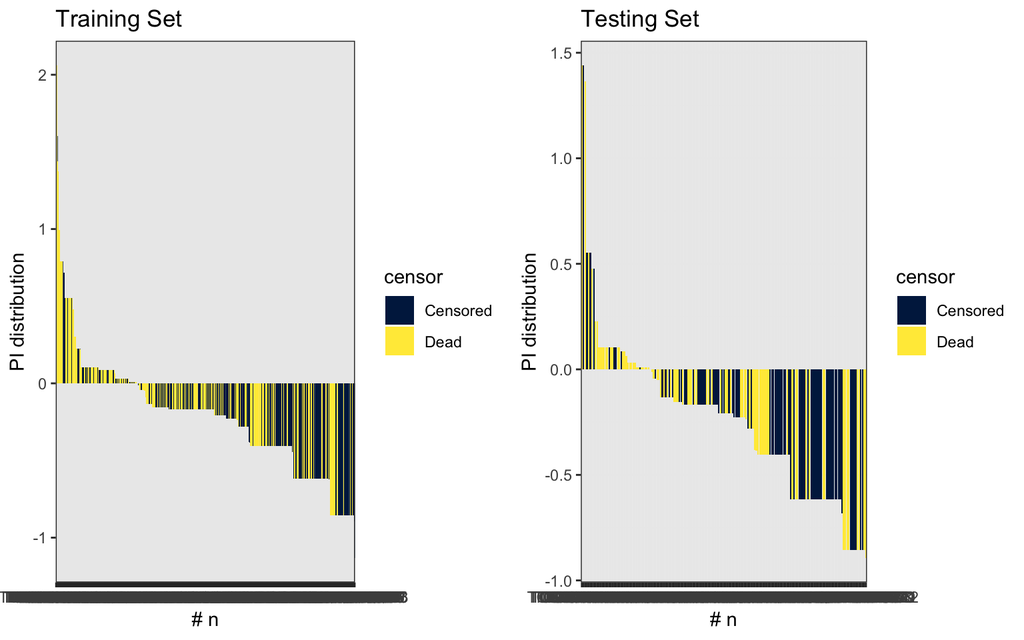

```r
ESNSCLC_train <- cbind(ESNSCLC_train,PI_train)
ESNSCLC_test <- cbind(ESNSCLC_test,PI_test)
ESNSCLC_train$censor <- ifelse(ESNSCLC_train$status == 1, "Censored", "Dead")
ESNSCLC_test$censor <- ifelse(ESNSCLC_test$status == 1, "Censored", "Dead")

p1 <- ggplot(ESNSCLC_train,aes(x= reorder(subj_id,-PI_train),PI_train,fill =censor))+
  geom_bar(stat ="identity") +
  scale_fill_viridis_d(option = "cividis") +
  labs(title = "Training Set",
       x = "# n",
       y = "PI distribution") +
  theme_bw()

p2 <- ggplot(ESNSCLC_test,aes(x= reorder(subj_id,-PI_test),PI_test, fill = censor)) +
  geom_bar(stat ="identity") +
  scale_fill_viridis_d(option = "cividis") +
  labs(title = "Testing Set",
       x = "# n",
       y = "PI distribution") +
  theme_bw()


gridExtra::grid.arrange(p1, p2, nrow = 1)
```

In this example there are no obvious outliers or other irregularities.

# 9 Validation

External validation denotes evaluation of model performance in a sample independent of that used to develop the model. Here is a structured way which aspects of the model can be validated for each level of information available for the derivation dataset.

## 9.1 Method 1: Regression on PI in validation data

A recognised approach to validation is to estimate the regression coefficient on the PI or risk score in the validation dataset.The discrimination in the validation dataset is about the same when the slope on the PI is approximately 1. If the slope in the validation dataset is < 1, discrimination is poorer, and conversely if it is > 1, discrimination is better.

```r
train_cox <- coxph(Surv(time, status) ~ PI_train, data = ESNSCLC_train)
#summary(train_cox)
train_cox[["coefficients"]]
```

```
PI_train
       1
```

```r
test_cox <- coxph(Surv(time, status) ~ PI_test, data = ESNSCLC_test)
#summary(test_cox)
test_cox[["coefficients"]]
```

```
 PI_test
1.002282
```

## 9.2 Method 2: Check model misspecification/fit

```r
entire_model <- coxph(Surv(time, status) ~ pathologic_stage  + diagnosis + pathologic_N, data = ESNSCLC_test)
coef.mple1 <- as.numeric(entire_model$coef)
chisq.test(coef.mple1, coef.mple)
```

```
    Pearson's Chi-squared test

data:  coef.mple1 and coef.mple
X-squared = 132, df = 121, p-value = 0.2329
```

## 9.3 Method 3: Measures of discrimination

```r
summary(train_cox)
```

```
Call:
coxph(formula = Surv(time, status) ~ PI_train, data = ESNSCLC_train)

  n= 502, number of events= 254

           coef exp(coef) se(coef)     z Pr(>|z|)
PI_train 1.0000    2.7183   0.1481 6.752 1.45e-11 ***
---
Signif. codes:  0 '***' 0.001 '**' 0.01 '*' 0.05 '.' 0.1 ' ' 1

         exp(coef) exp(-coef) lower .95 upper .95
PI_train     2.718     0.3679     2.033     3.634

Concordance= 0.617  (se = 0.02 )
Rsquare= 0.074   (max possible= 0.995 )
Likelihood ratio test= 38.43  on 1 df,   p=6e-10
Wald test            = 45.59  on 1 df,   p=1e-11
Score (logrank) test = 43.02  on 1 df,   p=5e-11
```

```r
summary(test_cox)
```

```
Call:
coxph(formula = Surv(time, status) ~ PI_test, data = ESNSCLC_test)

  n= 167, number of events= 86

          coef exp(coef) se(coef)     z Pr(>|z|)
PI_test 1.0023    2.7245   0.2714 3.692 0.000222 ***
---
Signif. codes:  0 '***' 0.001 '**' 0.01 '*' 0.05 '.' 0.1 ' ' 1

        exp(coef) exp(-coef) lower .95 upper .95
PI_test     2.724      0.367       1.6     4.638

Concordance= 0.643  (se = 0.035 )
Rsquare= 0.071   (max possible= 0.988 )
Likelihood ratio test= 12.26  on 1 df,   p=5e-04
Wald test            = 13.63  on 1 df,   p=2e-04
Score (logrank) test = 13.3  on 1 df,   p=3e-04
```

## 9.4 Method 4: Kaplan-Meier curves for risk groups

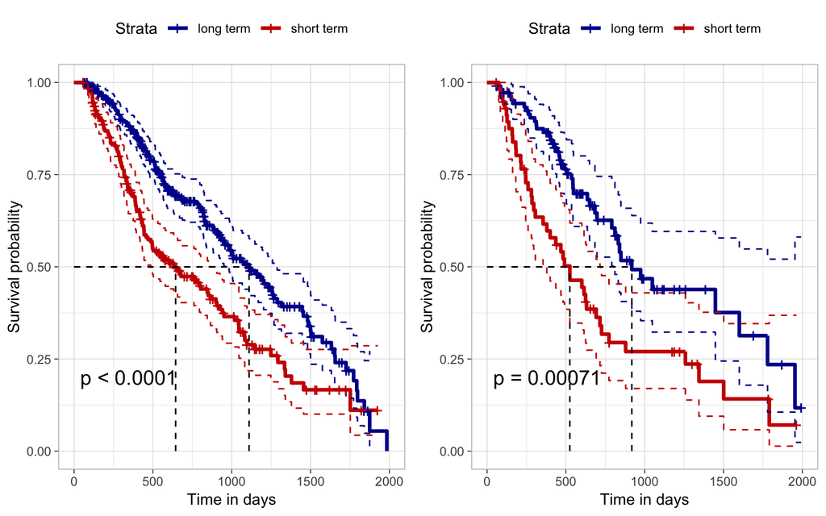

```r
med <- median(ESNSCLC_train$PI_train)
ESNSCLC_train$Rec1 <- ifelse(ESNSCLC_train$PI_train>med, 1,0)
fit2 <- survfit(Surv(time, status) ~ Rec1, data = ESNSCLC_train)
p1 <- ggsurvplot(
      fit2,
      data = ESNSCLC_train,
      size = 1.2,
      palette = c("#000099", "#CC0000"),
      risk.table = TRUE,
      pval = TRUE,
      conf.int = TRUE,
      label.curves = TRUE,
      xlim = c(0,2000),
      break.time.by = 500,
      xlab = "Time in days",
      ggtheme = theme_light(),
      risk.table.y.text.col = T,
      risk.table.y.text = FALSE,
      conf.int.style = "step",
      surv.median.line = "hv",
      legend.labs = c("long term", "short term"),
      tables.theme =  theme_cleantable())
ESNSCLC_test$Rec1 <- ifelse(ESNSCLC_test$PI_test > med, 1,0)
fit2 <- survfit(Surv(time, status) ~ Rec1, data = ESNSCLC_test)
p2 <- ggsurvplot(
      fit2,
      data = ESNSCLC_test,
      size = 1.2,
      palette = c("#000099", "#CC0000"),
      risk.table = TRUE,
      pval = TRUE,
      conf.int = TRUE,
      label.curves = TRUE,
      xlim = c(0,2000),
      break.time.by = 500,
      xlab = "Time in days",
      ggtheme = theme_light(),
      risk.table.y.text.col = T,
      risk.table.y.text = FALSE,
      conf.int.style = "step",
      surv.median.line = "hv",
      legend.labs = c("long term", "short term"),
      tables.theme =  theme_cleantable())

gridExtra::grid.arrange(p1$plot, p2$plot, nrow = 1)
```

```r
summary(train_cox)
```

```
Call:
coxph(formula = Surv(time, status) ~ PI_train, data = ESNSCLC_train)

  n= 502, number of events= 254

           coef exp(coef) se(coef)     z Pr(>|z|)
PI_train 1.0000    2.7183   0.1481 6.752 1.45e-11 ***
---
Signif. codes:  0 '***' 0.001 '**' 0.01 '*' 0.05 '.' 0.1 ' ' 1

         exp(coef) exp(-coef) lower .95 upper .95
PI_train     2.718     0.3679     2.033     3.634

Concordance= 0.617  (se = 0.02 )
Rsquare= 0.074   (max possible= 0.995 )
Likelihood ratio test= 38.43  on 1 df,   p=6e-10
Wald test            = 45.59  on 1 df,   p=1e-11
Score (logrank) test = 43.02  on 1 df,   p=5e-11
```

```r
summary(test_cox)
```

```
Call:
coxph(formula = Surv(time, status) ~ PI_test, data = ESNSCLC_test)

  n= 167, number of events= 86

          coef exp(coef) se(coef)     z Pr(>|z|)
PI_test 1.0023    2.7245   0.2714 3.692 0.000222 ***
---
Signif. codes:  0 '***' 0.001 '**' 0.01 '*' 0.05 '.' 0.1 ' ' 1

        exp(coef) exp(-coef) lower .95 upper .95
PI_test     2.724      0.367       1.6     4.638

Concordance= 0.643  (se = 0.035 )
Rsquare= 0.071   (max possible= 0.988 )
Likelihood ratio test= 12.26  on 1 df,   p=5e-04
Wald test            = 13.63  on 1 df,   p=2e-04
Score (logrank) test = 13.3  on 1 df,   p=3e-04
```

Pranjal Vaidya

2019-07-30